# E1A-induced chemosensitization

Elena Kalita

2026-05-13

# Aim of analysis

**E1A-induced chemosensitization**

Main question:

> How does E1A expression alter the transcriptional response of XCT116 cells to oxaliplatin?

For this we need interaction contrast:

```
(oxpl_E1A - ctrl_E1A) - (oxpl - ctrl)
```

That is, we are not simply comparing `oxpl_E1A vs oxpl`, but we are checking whether the response to oxaliplatin has changed in the presence of E1A.

This RMD includes two analyses:

1. All 24 samples: cell line-corrected model.
2. Only sensitive HCT116: ctrl, E1A, oxpl, oxpl_E1A.

# import Salmon quant.sf

```r
samples <- list.files("Salmon quant", full.names = TRUE)
files <- file.path(samples, "quant.sf")
names(files) <- basename(samples)
```

```r
tx2gene <- read.csv(gzfile("data/gencode.v47.metadata.HGNC.gz"), sep = "\t", header = FALSE)

txi_gene <- tximport(files, type = "salmon", tx2gene = tx2gene, countsFromAbundance = "no")
```

```
## reading in files with read_tsv
```

```
## 1 2 3 4 5 6 7 8 9 10 11 12 13 14 15 16 17 18 19 20 21 22 23 24
## transcripts missing from tx2gene: 117038
## summarizing abundance
## summarizing counts
## summarizing length
## summarizing inferential replicates
```

```r
txi_gene_RPK <- txi_gene$counts / txi_gene$length
txi_gene_TPM <- tximport(files, type = "salmon", tx2gene = tx2gene, countsFromAbundance = "lengthScaledTPM")
```

```
## reading in files with read_tsv
## 1 2 3 4 5 6 7 8 9 10 11 12 13 14 15 16 17 18 19 20 21 22 23 24
## transcripts missing from tx2gene: 117038
## summarizing abundance
## summarizing counts
## summarizing length
## summarizing inferential replicates
```

```r
txi_counts <- data.frame(txi_gene$counts)
txi_TPM <- data.frame(txi_gene_TPM$counts)

write.table(txi_counts, file = "raw_counts_all_samples.txt", sep = "\t", row.names = TRUE, quote = FALSE)
write.csv2(txi_counts, file = "raw_counts_all_samples.csv", row.names = TRUE, quote = FALSE)
write.csv2(txi_TPM, file = "TPM_all_samples.csv", row.names = TRUE, quote = FALSE)
```

# Metadata

```r
metadata <- data.frame(
  full_condition = factor(rep(c("ctrl", "E1A", "oxpl", "oxpl_E1A"), each = 3, times = 2)),
  condition = factor(rep(c("ctrl", "oxpl"), each = 6, times = 2)),
  e1a_status = factor(rep(c("negative", "positive"), each = 3, times = 4)),
  cell_line = factor(rep(c("HCT116", "HCT116_oxpl_R"), each = 12)),
  stat = factor(rep(c("ctrl", "ctrl_E1A", "oxpl", "oxpl_E1A",
                      "R_ctrl", "R_ctrl_E1A", "R_oxpl", "R_oxpl_E1A"), each = 3))
)

rownames(metadata) <- colnames(txi_gene$counts)

metadata$condition <- relevel(metadata$condition, ref = "ctrl")
metadata$e1a_status <- relevel(metadata$e1a_status, ref = "negative")
metadata$cell_line <- relevel(metadata$cell_line, ref = "HCT116")

metadata$sample_label <- paste0(metadata$stat, "_rep", rep(1:3, times = 8))
metadata
```

```
##                        full_condition condition e1a_status     cell_line
## Unknown_CG769-002U0029           ctrl      ctrl   negative        HCT116
## Unknown_CG769-002U0030           ctrl      ctrl   negative        HCT116
## Unknown_CG769-002U0031           ctrl      ctrl   negative        HCT116
## Unknown_CG769-002U0032            E1A      ctrl   positive        HCT116
## Unknown_CG769-002U0033            E1A      ctrl   positive        HCT116
## Unknown_CG769-002U0034            E1A      ctrl   positive        HCT116
## Unknown_CG769-002U0035           oxpl      oxpl   negative        HCT116
## Unknown_CG769-002U0036           oxpl      oxpl   negative        HCT116
## Unknown_CG769-002U0037           oxpl      oxpl   negative        HCT116
## Unknown_CG769-002U0038       oxpl_E1A      oxpl   positive        HCT116
## Unknown_CG769-002U0039       oxpl_E1A      oxpl   positive        HCT116
## Unknown_CG769-002U0040       oxpl_E1A      oxpl   positive        HCT116
## Unknown_CG769-002U0041           ctrl      ctrl   negative HCT116_oxpl_R
## Unknown_CG769-002U0042           ctrl      ctrl   negative HCT116_oxpl_R
## Unknown_CG769-002U0043           ctrl      ctrl   negative HCT116_oxpl_R
## Unknown_CG769-002U0044            E1A      ctrl   positive HCT116_oxpl_R
## Unknown_CG769-002U0045            E1A      ctrl   positive HCT116_oxpl_R
## Unknown_CG769-002U0046            E1A      ctrl   positive HCT116_oxpl_R
## Unknown_CG769-002U0047           oxpl      oxpl   negative HCT116_oxpl_R
## Unknown_CG769-002U0048           oxpl      oxpl   negative HCT116_oxpl_R
## Unknown_CG769-002U0049           oxpl      oxpl   negative HCT116_oxpl_R
## Unknown_CG769-002U0050       oxpl_E1A      oxpl   positive HCT116_oxpl_R
## Unknown_CG769-002U0051       oxpl_E1A      oxpl   positive HCT116_oxpl_R
## Unknown_CG769-002U0052       oxpl_E1A      oxpl   positive HCT116_oxpl_R
##                              stat    sample_label
## Unknown_CG769-002U0029       ctrl       ctrl_rep1
## Unknown_CG769-002U0030       ctrl       ctrl_rep2
## Unknown_CG769-002U0031       ctrl       ctrl_rep3
## Unknown_CG769-002U0032   ctrl_E1A   ctrl_E1A_rep1
## Unknown_CG769-002U0033   ctrl_E1A   ctrl_E1A_rep2
## Unknown_CG769-002U0034   ctrl_E1A   ctrl_E1A_rep3
## Unknown_CG769-002U0035       oxpl       oxpl_rep1
## Unknown_CG769-002U0036       oxpl       oxpl_rep2
## Unknown_CG769-002U0037       oxpl       oxpl_rep3
## Unknown_CG769-002U0038   oxpl_E1A   oxpl_E1A_rep1
## Unknown_CG769-002U0039   oxpl_E1A   oxpl_E1A_rep2
## Unknown_CG769-002U0040   oxpl_E1A   oxpl_E1A_rep3
## Unknown_CG769-002U0041     R_ctrl     R_ctrl_rep1
## Unknown_CG769-002U0042     R_ctrl     R_ctrl_rep2
## Unknown_CG769-002U0043     R_ctrl     R_ctrl_rep3
## Unknown_CG769-002U0044 R_ctrl_E1A R_ctrl_E1A_rep1
## Unknown_CG769-002U0045 R_ctrl_E1A R_ctrl_E1A_rep2
## Unknown_CG769-002U0046 R_ctrl_E1A R_ctrl_E1A_rep3
## Unknown_CG769-002U0047     R_oxpl     R_oxpl_rep1
## Unknown_CG769-002U0048     R_oxpl     R_oxpl_rep2
## Unknown_CG769-002U0049     R_oxpl     R_oxpl_rep3
## Unknown_CG769-002U0050 R_oxpl_E1A R_oxpl_E1A_rep1
## Unknown_CG769-002U0051 R_oxpl_E1A R_oxpl_E1A_rep2
## Unknown_CG769-002U0052 R_oxpl_E1A R_oxpl_E1A_rep3
```

# 1. All 24 samples

The full factorial model is used here:

```
~ cell_line * e1a_status * condition
```

It takes into account the main effects of cell line, E1A, and oxaliplatin,  
as well as all two- and three-way interactions.  
The main coefficient e1a_statuspositive.conditionoxpl shows  
how E1A modifies the response to oxaliplatin in HCT116.

## DESeq2 model: 24 samples

```r
dds_24 <- DESeqDataSetFromTximport(
  txi = txi_gene,
  colData = metadata,
  design = ~ cell_line * e1a_status * condition
)
```

```
## using counts and average transcript lengths from tximport
```

```r
dds_24 <- DESeq(dds_24)
```

```
## using 'avgTxLength' from assays(dds), correcting for library size
```

```r
dds_24 <- dds_24[rowSums(counts(dds_24)) > 0, ]

resultsNames(dds_24)
```

```
## [1] "Intercept"
## [2] "cell_line_HCT116_oxpl_R_vs_HCT116"
## [3] "e1a_status_positive_vs_negative"
## [4] "condition_oxpl_vs_ctrl"
## [5] "cell_lineHCT116_oxpl_R.e1a_statuspositive"
## [6] "cell_lineHCT116_oxpl_R.conditionoxpl"
## [7] "e1a_statuspositive.conditionoxpl"
## [8] "cell_lineHCT116_oxpl_R.e1a_statuspositive.conditionoxpl"
```

## Main contrast: E1A changes oxaliplatin response, 24 samples

```r
res_24 <- results(dds_24, name = "e1a_statuspositive.conditionoxpl", alpha = 0.05)
summary(res_24)
```

```
##
## out of 24918 with nonzero total read count
## adjusted p-value < 0.05
## LFC > 0 (up)       : 4, 0.016%
## LFC < 0 (down)     : 8, 0.032%
## outliers [1]       : 28, 0.11%
## low counts [2]     : 9644, 39%
## (mean count < 7)
## [1] see 'cooksCutoff' argument of ?results
## [2] see 'independentFiltering' argument of ?results
```

```r
res_24_df <- as.data.frame(res_24)
res_24_df$gene <- rownames(res_24_df)

res_24_clean <- res_24_df[!is.na(res_24_df$padj) & !is.na(res_24_df$log2FoldChange), ]
res_24_sig <- res_24_clean[res_24_clean$padj < 0.05 & abs(res_24_clean$log2FoldChange) > 1, ]
res_24_up <- res_24_sig[res_24_sig$log2FoldChange > 1, ]
res_24_down <- res_24_sig[res_24_sig$log2FoldChange < -1, ]

metrics_24 <- data.frame(
  analysis = "24_samples",
  contrast = "E1A_changes_oxaliplatin_response",
  formula = "~ cell_line * e1a_status * condition",
  n_total_nonzero = nrow(res_24_df),
  n_with_pvalue = sum(!is.na(res_24_df$pvalue)),
  n_with_padj = sum(!is.na(res_24_df$padj)),
  n_sig_padj_0_05_absLFC_1 = nrow(res_24_sig),
  n_up = nrow(res_24_up),
  n_down = nrow(res_24_down)
)

metrics_24
```

```
##     analysis                         contrast
## 1 24_samples E1A_changes_oxaliplatin_response
##                                formula n_total_nonzero n_with_pvalue
## 1 ~ cell_line * e1a_status * condition           24918         24890
##   n_with_padj n_sig_padj_0_05_absLFC_1 n_up n_down
## 1       15246                       10    4      6
```

```r
write.csv(res_24_df, "E1A_chemosens_24_all_DESeq2_results.csv", row.names = FALSE)
write.csv(res_24_sig, "E1A_chemosens_24_significant_DEG.csv", row.names = FALSE)
write.csv(metrics_24, "E1A_chemosens_24_metrics.csv", row.names = FALSE)
```

## Top DEG: 24 samples

```r
top30_24 <- head(res_24_clean[order(res_24_clean$padj), ], 30)
top30_24[, c("gene", "log2FoldChange", "pvalue", "padj")]
```

```
##                          gene log2FoldChange       pvalue         padj
## SULF2                   SULF2     -1.5654629 5.505691e-10 8.393976e-06
## DUSP1                   DUSP1     -0.9003225 4.891894e-07 3.729091e-03
## DSP-AS1               DSP-AS1     -2.4794029 1.020251e-06 5.184913e-03
## CCN2                     CCN2     -1.4336246 5.055413e-06 1.926871e-02
## CDKN1A                 CDKN1A     -0.9447374 6.681887e-06 2.037441e-02
## NSUN5P1               NSUN5P1     16.2506048 8.331383e-06 2.117004e-02
## KLK11                   KLK11     -3.6703431 1.701709e-05 3.706322e-02
## ITGB7                   ITGB7      3.5490136 2.320906e-05 4.227253e-02
## SPEF2                   SPEF2      2.9390031 2.495427e-05 4.227253e-02
## CASTOR3P             CASTOR3P     -1.7020962 3.128195e-05 4.408629e-02
## LINC00659           LINC00659     -2.1560409 3.180829e-05 4.408629e-02
## RTEL1-TNFRSF6B RTEL1-TNFRSF6B      1.3055199 3.922864e-05 4.983998e-02
## CALCOCO1             CALCOCO1     -0.9444327 7.480675e-05 6.708845e-02
## LAMA3                   LAMA3     -1.2579520 6.467478e-05 6.708845e-02
## PADI3                   PADI3     -1.9130415 5.918929e-05 6.708845e-02
## SMPD1                   SMPD1     -1.2672808 6.722007e-05 6.708845e-02
## ZCCHC12               ZCCHC12     -0.8520756 7.397264e-05 6.708845e-02
## ZDHHC24               ZDHHC24     -0.8168825 8.137618e-05 6.892563e-02
## PKDCC                   PKDCC     -2.4707678 9.640903e-05 7.699150e-02
## TNXB                     TNXB     -1.5724975 1.009989e-04 7.699150e-02
## FAM225A               FAM225A     -6.3386725 1.097600e-04 7.968573e-02
## ASAH2                   ASAH2      4.6464765 1.435166e-04 9.513281e-02
## PRICKLE1             PRICKLE1     -2.1411037 1.401316e-04 9.513281e-02
## HEY2                     HEY2     -5.7897651 1.560323e-04 9.911950e-02
## CCDC80                 CCDC80     -3.4985222 1.941533e-04 1.184024e-01
## VPS11-DT             VPS11-DT     -4.4456936 2.170611e-04 1.272813e-01
## KIN                       KIN      1.2293063 2.343282e-04 1.323173e-01
## GABPB2                 GABPB2      1.1172212 2.710983e-04 1.425229e-01
## GPR37L1               GPR37L1     -3.4043002 2.641095e-04 1.425229e-01
## LINC01730           LINC01730      2.5365104 3.055205e-04 1.552655e-01
```

```r
write.csv(top30_24, "E1A_chemosens_24_top30_DEG.csv", row.names = FALSE)
```

## MA-plot: 24 samples

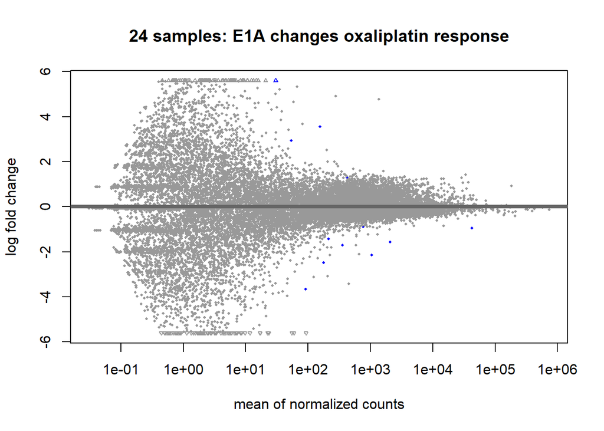

```r
plotMA(res_24, main = "24 samples: E1A changes oxaliplatin response")
```

## VST and heatmap top-30: 24 samples

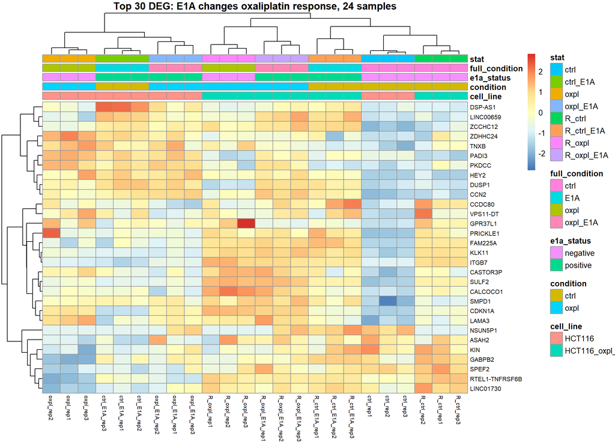

```r
vsd_24 <- vst(dds_24, blind = FALSE)

mat_24 <- assay(vsd_24)[top30_24$gene, ]
colnames(mat_24) <- metadata$sample_label

annotation_24 <- as.data.frame(colData(dds_24)[, c("cell_line", "condition", "e1a_status", "full_condition", "stat")])
rownames(annotation_24) <- metadata$sample_label

pheatmap(
  mat_24,
  scale = "row",
  annotation_col = annotation_24,
  clustering_distance_rows = "correlation",
  clustering_distance_cols = "correlation",
  fontsize_row = 8,
  fontsize_col = 7,
  main = "Top 30 DEG: E1A changes oxaliplatin response, 24 samples"
)
```

## Volcano plot: 24 samples

```r
EnhancedVolcano(
  res_24,
  lab = rownames(res_24),
  x = "log2FoldChange",
  y = "pvalue",
  pCutoffCol = "padj",
  title = "Full DESeq model: E1A changes oxaliplatin response",
  FCcutoff = 1,
  pCutoff = 0.05,
  pointSize = 2.5,
  labSize = 4
)
```

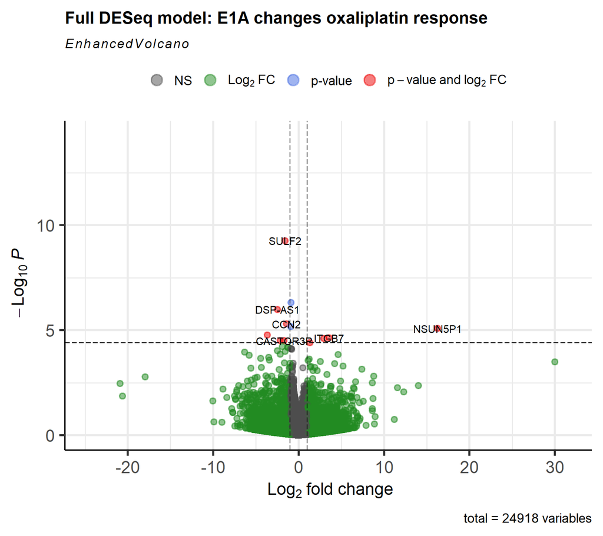

## Boxplots for up- and down-regulated genes: 24 samples

We take the top up- and down-regulated genes from the DESeq2 result for the main interaction contrast. Here, `up` denotes positive `log2FoldChange`, `down` denotes negative `log2FoldChange`.

```r
boxplot_up_24 <- head(res_24_up[order(res_24_up$padj), ], 6)
boxplot_down_24 <- head(res_24_down[order(res_24_down$padj), ], 6)

boxplot_genes_24 <- c(boxplot_up_24$gene, boxplot_down_24$gene)
boxplot_direction_24 <- c(rep("up", nrow(boxplot_up_24)), rep("down", nrow(boxplot_down_24)))

boxplot_table_24 <- data.frame(
  gene = boxplot_genes_24,
  direction = boxplot_direction_24
)

boxplot_table_24
```

```
##              gene direction
## 1         NSUN5P1        up
## 2           ITGB7        up
## 3           SPEF2        up
## 4  RTEL1-TNFRSF6B        up
## 5           SULF2      down
## 6         DSP-AS1      down
## 7            CCN2      down
## 8           KLK11      down
## 9        CASTOR3P      down
## 10      LINC00659      down
```

```r
write.csv(boxplot_table_24, "E1A_chemosens_24_boxplot_genes.csv", row.names = FALSE)
```

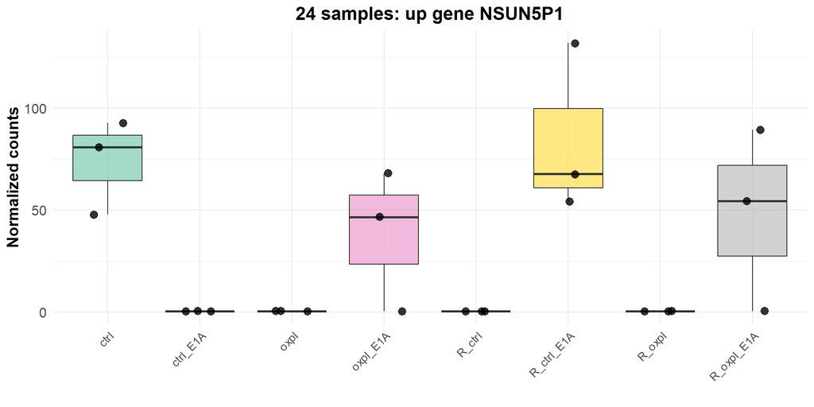

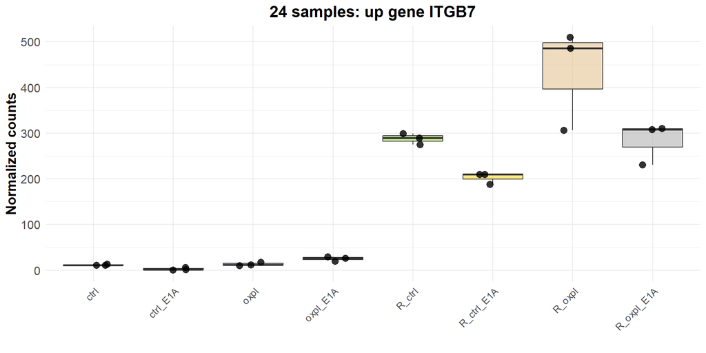

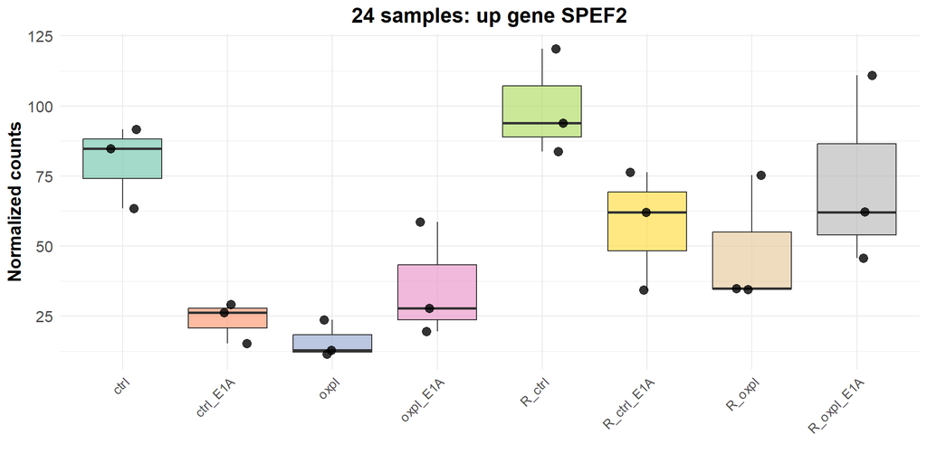

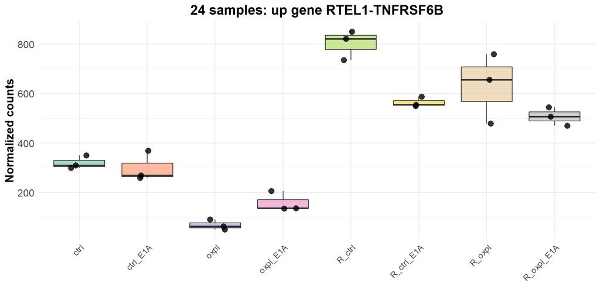

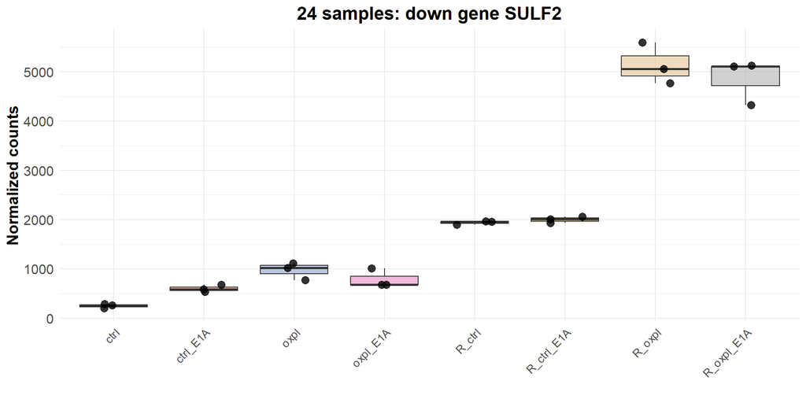

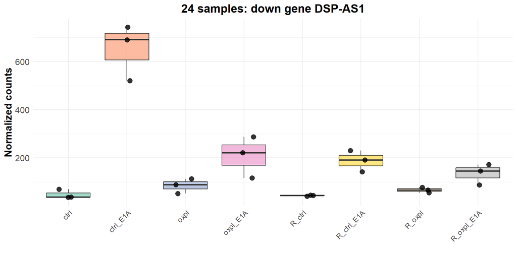

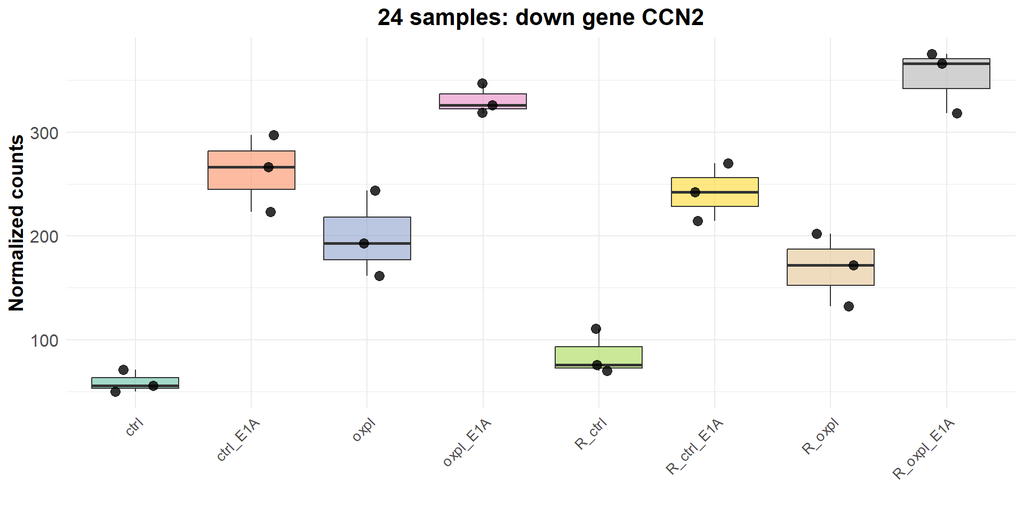

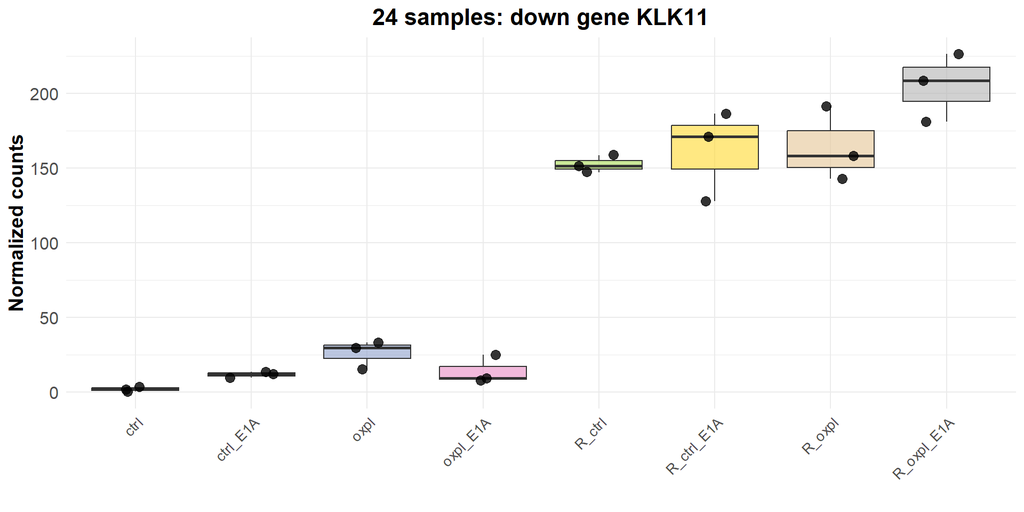

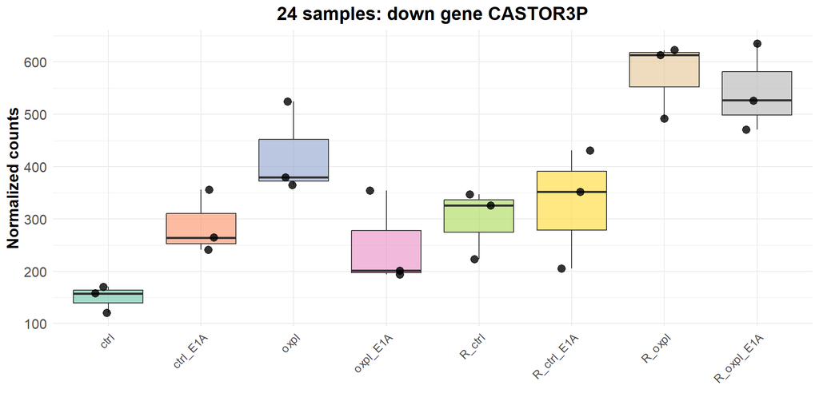

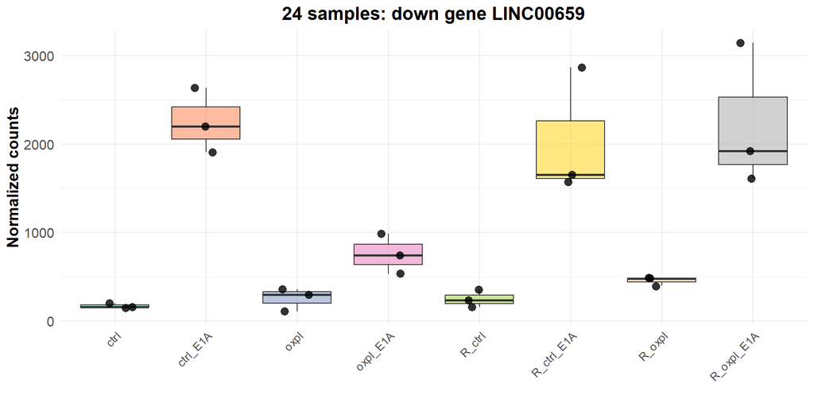

```r
dir.create("boxplots_E1A_chemosens_24", showWarnings = FALSE)

for (i in seq_along(boxplot_genes_24)) {
  gene <- boxplot_genes_24[i]
  direction <- boxplot_direction_24[i]

  ge <- plotCounts(dds_24, gene = gene, intgroup = "stat", returnData = TRUE)

  p <- ggplot(ge, aes(x = stat, y = count, fill = stat)) +
    geom_boxplot(outlier.shape = NA, alpha = 0.6) +
    geom_jitter(width = 0.2, size = 3, alpha = 0.8) +
    scale_fill_brewer(palette = "Set2") +
    labs(
      title = paste("24 samples:", direction, "gene", gene),
      x = "",
      y = "Normalized counts"
    ) +
    theme_minimal() +
    theme(
      legend.position = "none",
      axis.text.x = element_text(size = 10, angle = 45, hjust = 1),
      axis.text.y = element_text(size = 12),
      axis.title = element_text(size = 14, face = "bold"),
      plot.title = element_text(size = 16, face = "bold", hjust = 0.5)
    )

  print(p)

  safe_gene <- gsub("[^A-Za-z0-9_.-]", "_", gene)
  ggsave(
    filename = file.path("boxplots_E1A_chemosens_24", paste0(direction, "_", safe_gene, "_boxplot.png")),
    plot = p,
    width = 10,
    height = 5,
    dpi = 300
  )
}
```

## GSEA ranking: 24 samples

For GSEA we use Wald test statistics (`stat`).

```r
gene_stat_24 <- res_24$stat
names(gene_stat_24) <- rownames(res_24)
gene_stat_24 <- na.omit(gene_stat_24)
gene_stat_24 <- sort(gene_stat_24, decreasing = TRUE)

head(gene_stat_24)
```

```
##        NSUN5P1          ITGB7          SPEF2          POTEI RTEL1-TNFRSF6B
##       4.456487       4.231546       4.215213       4.167853       4.111976
##          ASAH2
##       3.802028
```

## GSEA GO ALL: 24 samples

```r
gse_GO_24_ALL <- gseGO(
  geneList = gene_stat_24,
  ont = "ALL",
  keyType = "SYMBOL",
  minGSSize = 3,
  maxGSSize = 800,
  pvalueCutoff = 0.05,
  verbose = TRUE,
  OrgDb = org.Hs.eg.db,
  pAdjustMethod = "BH"
)
```

```
## using 'fgsea' for GSEA analysis, please cite Korotkevich et al (2019).
```

```
## preparing geneSet collections...
```

```
## GSEA analysis...
```

```
## leading edge analysis...
```

```
## done...
```

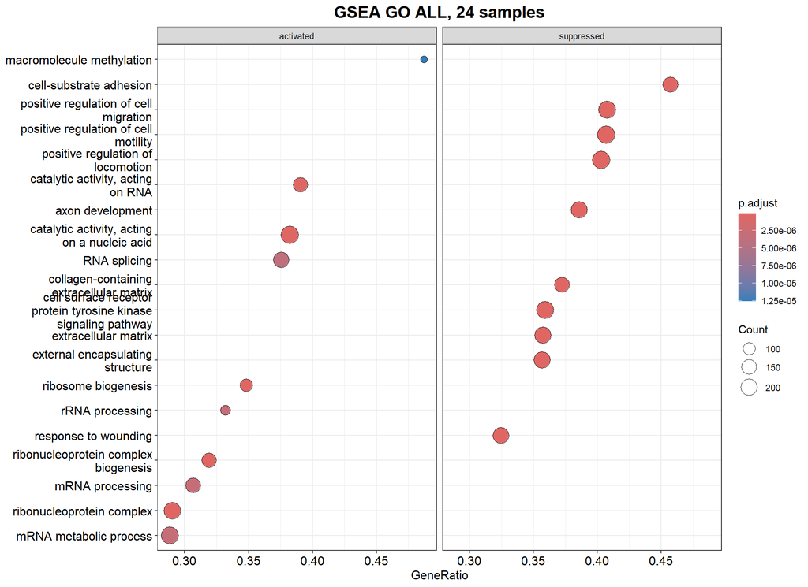

```r
write.csv(
  as.data.frame(gse_GO_24_ALL),
  "E1A_chemosens_24_GSEA_GO_ALL.csv",
  row.names = FALSE
)

dotplot(gse_GO_24_ALL, showCategory = 10, split = ".sign") +
  facet_grid(. ~ .sign) +
  labs(title = "GSEA GO ALL, 24 samples") +
  theme(
    plot.title = element_text(size = 16, face = "bold", hjust = 0.5)
  )
```

## GSEA GO BP: 24 samples

```r
gse_GO_24_BP <- gseGO(
  geneList = gene_stat_24,
  ont = "BP",
  keyType = "SYMBOL",
  minGSSize = 3,
  maxGSSize = 800,
  pvalueCutoff = 0.05,
  verbose = TRUE,
  OrgDb = org.Hs.eg.db,
  pAdjustMethod = "BH"
)
```

```
## using 'fgsea' for GSEA analysis, please cite Korotkevich et al (2019).
```

```
## preparing geneSet collections...
```

```
## GSEA analysis...
```

```
## leading edge analysis...
```

```
## done...
```

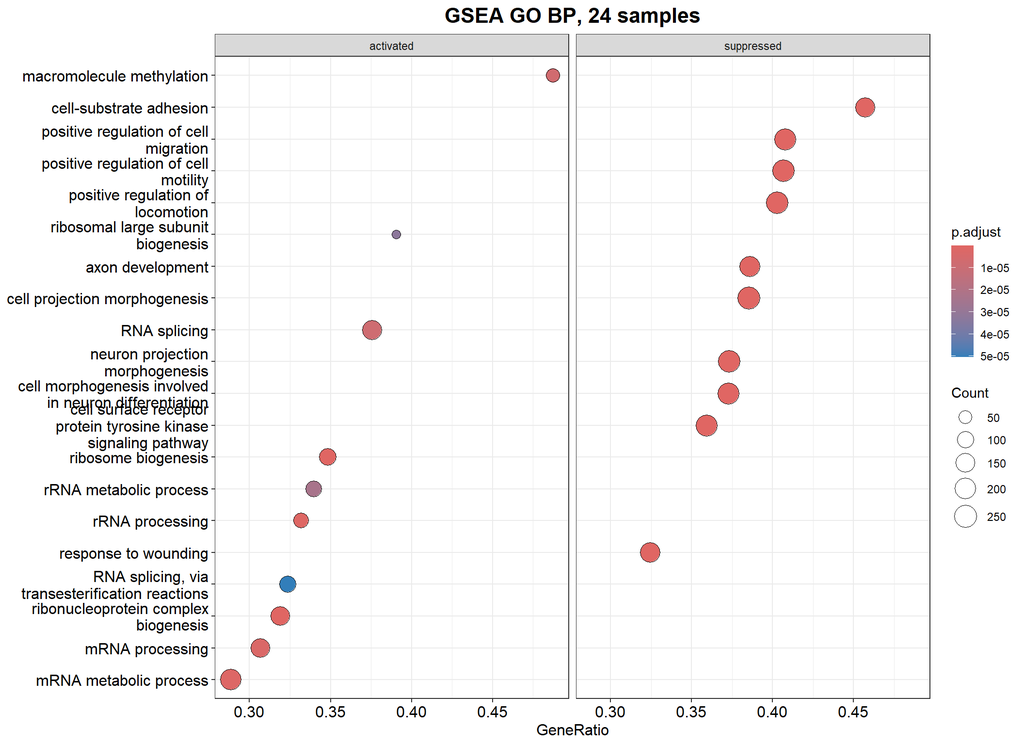

```r
write.csv(as.data.frame(gse_GO_24_BP), "E1A_chemosens_24_GSEA_GO_BP.csv", row.names = FALSE)

dotplot(gse_GO_24_BP, showCategory = 10, split = ".sign") +
  facet_grid(. ~ .sign) +
  labs(title = "GSEA GO BP, 24 samples") +
  theme(
    plot.title = element_text(size = 16, face = "bold", hjust = 0.5)
  )
```

## GSEA GO CC: 24 samples

```r
gse_GO_24_CC <- gseGO(
  geneList = gene_stat_24,
  ont = "CC",
  keyType = "SYMBOL",
  minGSSize = 3,
  maxGSSize = 800,
  pvalueCutoff = 0.05,
  verbose = TRUE,
  OrgDb = org.Hs.eg.db,
  pAdjustMethod = "BH"
)
```

```
## using 'fgsea' for GSEA analysis, please cite Korotkevich et al (2019).
```

```
## preparing geneSet collections...
```

```
## GSEA analysis...
```

```
## leading edge analysis...
```

```
## done...
```

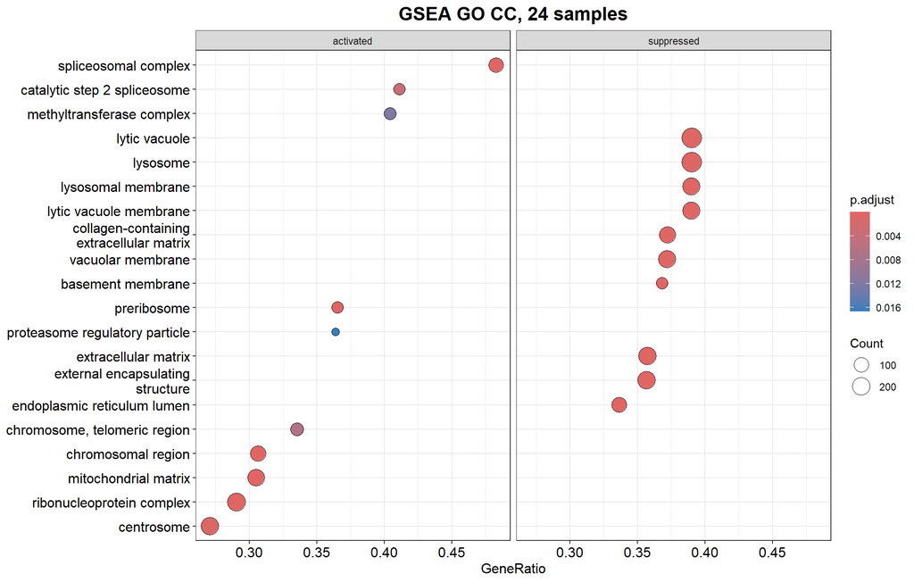

```r
write.csv(as.data.frame(gse_GO_24_CC), "E1A_chemosens_24_GSEA_GO_CC.csv", row.names = FALSE)

dotplot(gse_GO_24_CC, showCategory = 10, split = ".sign") +
  facet_grid(. ~ .sign) +
  labs(title = "GSEA GO CC, 24 samples") +
  theme(
    plot.title = element_text(size = 16, face = "bold", hjust = 0.5)
  )
```

## GSEA GO MF: 24 samples

```r
gse_GO_24_MF <- gseGO(
  geneList = gene_stat_24,
  ont = "MF",
  keyType = "SYMBOL",
  minGSSize = 3,
  maxGSSize = 800,
  pvalueCutoff = 0.05,
  verbose = TRUE,
  OrgDb = org.Hs.eg.db,
  pAdjustMethod = "BH"
)
```

```
## using 'fgsea' for GSEA analysis, please cite Korotkevich et al (2019).
```

```
## preparing geneSet collections...
```

```
## GSEA analysis...
```

```
## leading edge analysis...
```

```
## done...
```

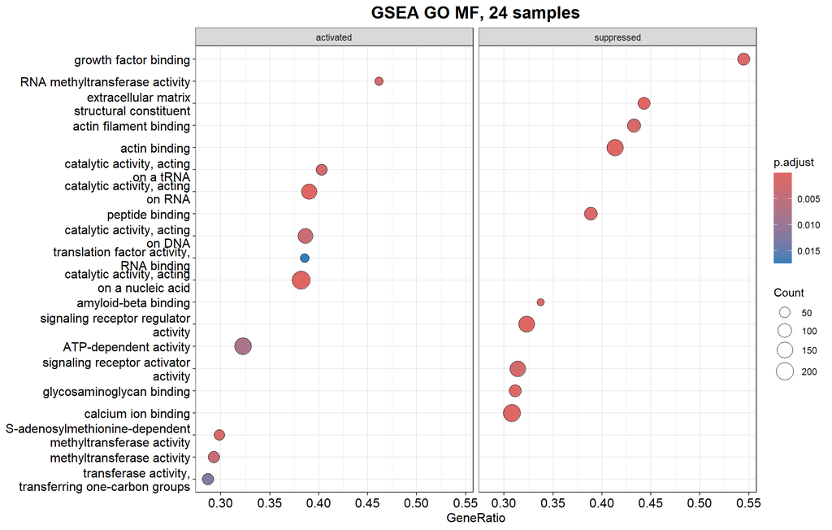

```r
write.csv(as.data.frame(gse_GO_24_MF), "E1A_chemosens_24_GSEA_GO_MF.csv", row.names = FALSE)

dotplot(gse_GO_24_MF, showCategory = 10, split = ".sign") +
  facet_grid(. ~ .sign) +
  labs(title = "GSEA GO MF, 24 samples") +
  theme(
    plot.title = element_text(size = 16, face = "bold", hjust = 0.5)
  )
```

## GSEA KEGG: 24 samples

```r
mapping_24 <- mapIds(
  org.Hs.eg.db,
  keys = names(gene_stat_24),
  column = "ENTREZID",
  keytype = "SYMBOL",
  multiVals = "first"
)
gene_list_entrez_24 <- gene_stat_24
names(gene_list_entrez_24) <- mapping_24

gene_list_entrez_24 <- gene_list_entrez_24[!is.na(names(gene_list_entrez_24))]
gene_list_entrez_24 <- gene_list_entrez_24[!duplicated(names(gene_list_entrez_24))]
gene_list_entrez_24 <- sort(gene_list_entrez_24, decreasing = TRUE)

gsea_kegg_24 <- gseKEGG(
  geneList = gene_list_entrez_24,
  organism = "hsa",
  keyType = "ncbi-geneid",
  pvalueCutoff = 0.05,
  pAdjustMethod = "BH"
)
```

```
## Reading KEGG annotation online: "https://rest.kegg.jp/link/hsa/pathway"...
```

```
## Reading KEGG annotation online: "https://rest.kegg.jp/list/pathway/hsa"...
```

```
## Reading KEGG annotation online: "https://rest.kegg.jp/conv/ncbi-geneid/hsa"...
```

```
## using 'fgsea' for GSEA analysis, please cite Korotkevich et al (2019).
```

```
## preparing geneSet collections...
```

```
## GSEA analysis...
```

```
## leading edge analysis...
```

```
## done...
```

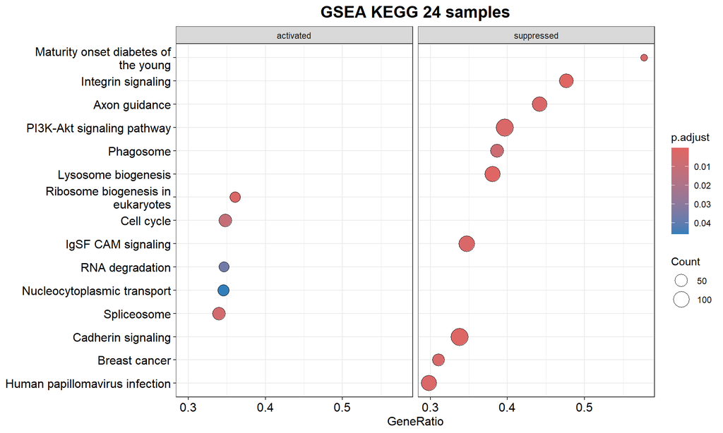

```r
gsea_kegg_24 <- setReadable(gsea_kegg_24, OrgDb = org.Hs.eg.db, keyType = "ENTREZID")

write.csv(as.data.frame(gsea_kegg_24), "E1A_chemosens_24_GSEA_KEGG.csv", row.names = FALSE)

dotplot(gsea_kegg_24, showCategory = 10, split = ".sign") +
  facet_grid(. ~ .sign) +
  labs(title = "GSEA KEGG 24 samples") +
  theme(
    plot.title = element_text(size = 16, face = "bold", hjust = 0.5)
  )
```

# 2. Only sensitive HCT116 cells

Now we leave only 12 HCT116 samples:

```
ctrl, E1A, oxpl, oxpl_E1A
```

Model:

```
~ e1a_status * condition
```

Main contrast:

```
(oxpl_E1A - ctrl_E1A) - (oxpl - ctrl)
```

## Subset HCT116

```r
metadata_HCT116 <- metadata[metadata$cell_line == "HCT116", ]
metadata_HCT116 <- droplevels(metadata_HCT116)

samples_HCT116 <- rownames(metadata_HCT116)

txi_HCT116 <- txi_gene
txi_HCT116$counts <- txi_gene$counts[, samples_HCT116]
txi_HCT116$abundance <- txi_gene$abundance[, samples_HCT116]
txi_HCT116$length <- txi_gene$length[, samples_HCT116]

metadata_HCT116$condition <- relevel(metadata_HCT116$condition, ref = "ctrl")
metadata_HCT116$e1a_status <- relevel(metadata_HCT116$e1a_status, ref = "negative")
metadata_HCT116$sample_label <- paste0(metadata_HCT116$stat, "_rep", rep(1:3, times = 4))

metadata_HCT116
```

```
##                        full_condition condition e1a_status cell_line     stat
## Unknown_CG769-002U0029           ctrl      ctrl   negative    HCT116     ctrl
## Unknown_CG769-002U0030           ctrl      ctrl   negative    HCT116     ctrl
## Unknown_CG769-002U0031           ctrl      ctrl   negative    HCT116     ctrl
## Unknown_CG769-002U0032            E1A      ctrl   positive    HCT116 ctrl_E1A
## Unknown_CG769-002U0033            E1A      ctrl   positive    HCT116 ctrl_E1A
## Unknown_CG769-002U0034            E1A      ctrl   positive    HCT116 ctrl_E1A
## Unknown_CG769-002U0035           oxpl      oxpl   negative    HCT116     oxpl
## Unknown_CG769-002U0036           oxpl      oxpl   negative    HCT116     oxpl
## Unknown_CG769-002U0037           oxpl      oxpl   negative    HCT116     oxpl
## Unknown_CG769-002U0038       oxpl_E1A      oxpl   positive    HCT116 oxpl_E1A
## Unknown_CG769-002U0039       oxpl_E1A      oxpl   positive    HCT116 oxpl_E1A
## Unknown_CG769-002U0040       oxpl_E1A      oxpl   positive    HCT116 oxpl_E1A
##                         sample_label
## Unknown_CG769-002U0029     ctrl_rep1
## Unknown_CG769-002U0030     ctrl_rep2
## Unknown_CG769-002U0031     ctrl_rep3
## Unknown_CG769-002U0032 ctrl_E1A_rep1
## Unknown_CG769-002U0033 ctrl_E1A_rep2
## Unknown_CG769-002U0034 ctrl_E1A_rep3
## Unknown_CG769-002U0035     oxpl_rep1
## Unknown_CG769-002U0036     oxpl_rep2
## Unknown_CG769-002U0037     oxpl_rep3
## Unknown_CG769-002U0038 oxpl_E1A_rep1
## Unknown_CG769-002U0039 oxpl_E1A_rep2
## Unknown_CG769-002U0040 oxpl_E1A_rep3
```

## DESeq2 model: HCT116 only

```r
dds_HCT116 <- DESeqDataSetFromTximport(
  txi = txi_HCT116,
  colData = metadata_HCT116,
  design = ~ e1a_status * condition
)
```

```
## using counts and average transcript lengths from tximport
```

```r
dds_HCT116 <- DESeq(dds_HCT116)
```

```
## using 'avgTxLength' from assays(dds), correcting for library size
```

```r
dds_HCT116 <- dds_HCT116[rowSums(counts(dds_HCT116)) > 0, ]

resultsNames(dds_HCT116)
```

```
## [1] "Intercept"                        "e1a_status_positive_vs_negative"
## [3] "condition_oxpl_vs_ctrl"           "e1a_statuspositive.conditionoxpl"
```

## Main contrast: E1A changes oxaliplatin response, HCT116 only

```r
res_HCT116 <- results(dds_HCT116, name = "e1a_statuspositive.conditionoxpl", alpha = 0.05)
summary(res_HCT116)
```

```
##
## out of 22681 with nonzero total read count
## adjusted p-value < 0.05
## LFC > 0 (up)       : 7, 0.031%
## LFC < 0 (down)     : 11, 0.048%
## outliers [1]       : 27, 0.12%
## low counts [2]     : 4398, 19%
## (mean count < 1)
## [1] see 'cooksCutoff' argument of ?results
## [2] see 'independentFiltering' argument of ?results
```

```r
res_HCT116_df <- as.data.frame(res_HCT116)
res_HCT116_df$gene <- rownames(res_HCT116_df)

res_HCT116_clean <- res_HCT116_df[!is.na(res_HCT116_df$padj) & !is.na(res_HCT116_df$log2FoldChange), ]
res_HCT116_sig <- res_HCT116_clean[res_HCT116_clean$padj < 0.05 & abs(res_HCT116_clean$log2FoldChange) > 1, ]
res_HCT116_up <- res_HCT116_sig[res_HCT116_sig$log2FoldChange > 1, ]
res_HCT116_down <- res_HCT116_sig[res_HCT116_sig$log2FoldChange < -1, ]

metrics_HCT116 <- data.frame(
  analysis = "HCT116_only",
  contrast = "E1A_changes_oxaliplatin_response",
  formula = "~ e1a_status * condition",
  n_total_nonzero = nrow(res_HCT116_df),
  n_with_pvalue = sum(!is.na(res_HCT116_df$pvalue)),
  n_with_padj = sum(!is.na(res_HCT116_df$padj)),
  n_sig_padj_0_05_absLFC_1 = nrow(res_HCT116_sig),
  n_up = nrow(res_HCT116_up),
  n_down = nrow(res_HCT116_down)
)

metrics_HCT116
```

```
##      analysis                         contrast                  formula
## 1 HCT116_only E1A_changes_oxaliplatin_response ~ e1a_status * condition
##   n_total_nonzero n_with_pvalue n_with_padj n_sig_padj_0_05_absLFC_1 n_up
## 1           22681         22654       18256                       15    7
##   n_down
## 1      8
```

```r
write.csv(res_HCT116_df, "E1A_chemosens_HCT116_all_DESeq2_results.csv", row.names = FALSE)
write.csv(res_HCT116_sig, "E1A_chemosens_HCT116_significant_DEG.csv", row.names = FALSE)
write.csv(metrics_HCT116, "E1A_chemosens_HCT116_metrics.csv", row.names = FALSE)
```

## Top DEG: HCT116 only

```r
top30_HCT116 <- head(res_HCT116_clean[order(res_HCT116_clean$padj), ], 30)
top30_HCT116[, c("gene", "log2FoldChange", "pvalue", "padj")]
```

```
##                            gene log2FoldChange       pvalue         padj
## JUNB                       JUNB     -0.8623042 6.236591e-09 0.0001138552
## PADI3                     PADI3     -1.9245121 8.666819e-07 0.0052740484
## ZDHHC24                 ZDHHC24     -0.8273049 6.638881e-07 0.0052740484
## ATP6V1G2-DDX39B ATP6V1G2-DDX39B      4.1999854 1.397755e-06 0.0053939649
## PKDCC                     PKDCC     -2.4708370 1.772775e-06 0.0053939649
## SULF2                     SULF2     -1.5783830 1.571726e-06 0.0053939649
## DSP-AS1                 DSP-AS1     -2.4851117 4.890933e-06 0.0120985446
## NSUN5P1                 NSUN5P1     16.2429142 5.301729e-06 0.0120985446
## GPR162                   GPR162     -1.2946297 6.079970e-06 0.0123328813
## CCN2                       CCN2     -1.4432952 7.430125e-06 0.0135644359
## AGAP13P                 AGAP13P     12.3136030 1.349869e-05 0.0214658767
## IFT57                     IFT57      1.3407016 1.410991e-05 0.0214658767
## DUSP1                     DUSP1     -0.9102620 1.685638e-05 0.0219807203
## LINC00659             LINC00659     -2.1574908 1.640280e-05 0.0219807203
## CASTOR3P               CASTOR3P     -1.7156358 3.297205e-05 0.0401291816
## ASAH2                     ASAH2      4.6569870 4.694829e-05 0.0496268360
## HNRNPA1L2             HNRNPA1L2      3.8868510 4.893093e-05 0.0496268360
## SPEF2                     SPEF2      2.9279906 4.369745e-05 0.0496268360
## VPS11-DT               VPS11-DT     -4.4417151 6.441139e-05 0.0618891709
## ZCCHC12                 ZCCHC12     -0.8632227 8.333788e-05 0.0760708172
## ARC                         ARC     -1.0271171 1.110656e-04 0.0965530408
## CDKN1A                   CDKN1A     -0.9547723 1.251379e-04 0.1032840835
## EFHD1                     EFHD1     -2.0520634 1.301235e-04 0.1032840835
## ACHE                       ACHE     -1.2892071 1.850375e-04 0.1407518446
## CHRNB4                   CHRNB4     -1.3435142 2.222746e-04 0.1502905895
## GDF1                       GDF1     -5.6011734 2.098333e-04 0.1502905895
## HNRNPDL                 HNRNPDL      0.6887245 2.213268e-04 0.1502905895
## KIN                         KIN      1.2226932 2.307863e-04 0.1504726927
## APOD                       APOD     -2.0459958 2.608427e-04 0.1527445345
## CCDC80                   CCDC80     -3.5117967 2.624046e-04 0.1527445345
```

```r
write.csv(top30_HCT116, "E1A_chemosens_HCT116_top30_DEG.csv", row.names = FALSE)
```

## MA-plot: HCT116 only

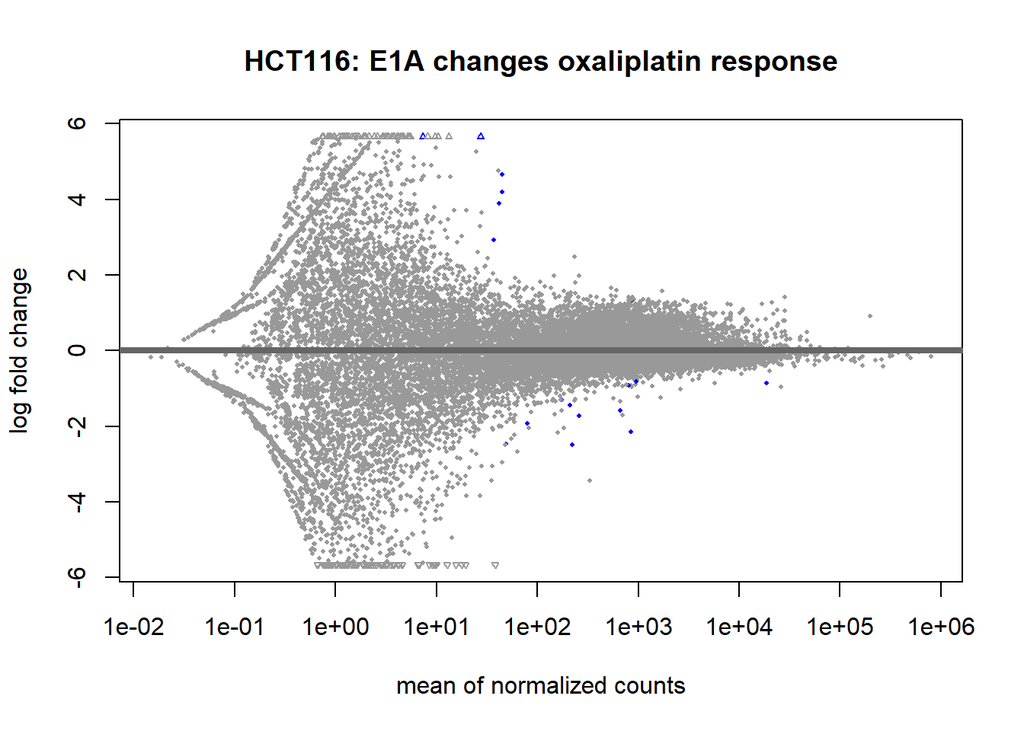

```r
plotMA(res_HCT116, main = "HCT116: E1A changes oxaliplatin response")
```

## VST and heatmap top-30: HCT116 only

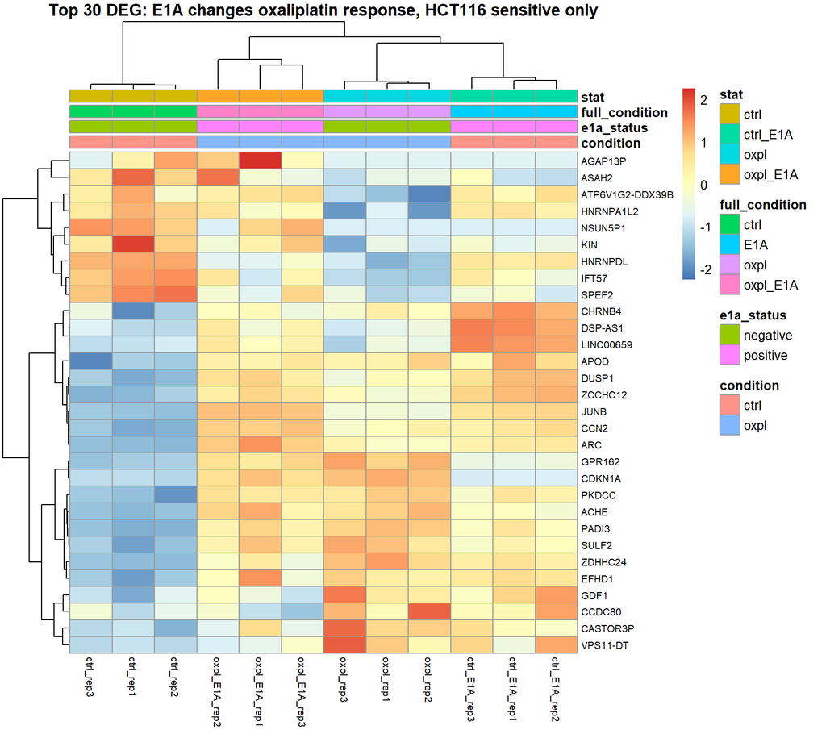

```r
vsd_HCT116 <- vst(dds_HCT116, blind = FALSE)

mat_HCT116 <- assay(vsd_HCT116)[top30_HCT116$gene, ]
colnames(mat_HCT116) <- metadata_HCT116$sample_label

annotation_HCT116 <- as.data.frame(colData(dds_HCT116)[, c("condition", "e1a_status", "full_condition", "stat")])
rownames(annotation_HCT116) <- metadata_HCT116$sample_label

pheatmap(
  mat_HCT116,
  scale = "row",
  annotation_col = annotation_HCT116,
  clustering_distance_rows = "correlation",
  clustering_distance_cols = "correlation",
  fontsize_row = 8,
  fontsize_col = 8,
  main = "Top 30 DEG: E1A changes oxaliplatin response, HCT116 sensitive only"
)
```

## Volcano plot: HCT116 only

```r
EnhancedVolcano(
  res_HCT116,
  lab = rownames(res_HCT116),
  x = "log2FoldChange",
  y = "pvalue",
  pCutoffCol = "padj",
  title = "E1A-induced chemosensitization",
  FCcutoff = 1,
  pCutoff = 0.05,
  pointSize = 2.5,
  labSize = 4
)
```

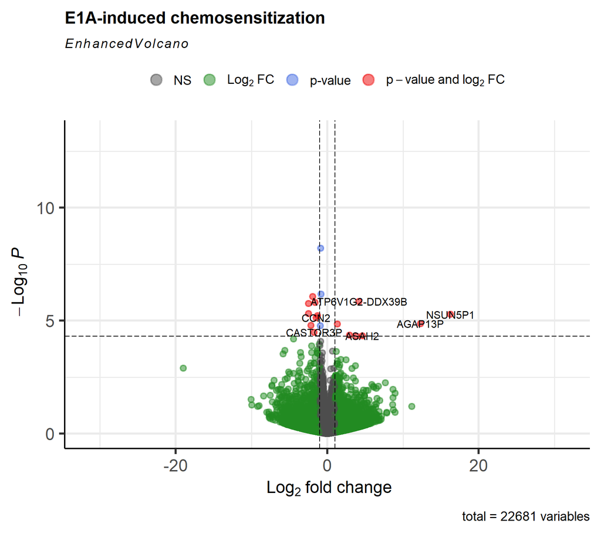

## Boxplots for up- and down-regulated genes: HCT116 only

We take the top up- and down-regulated genes from the DESeq2 result for interaction contrast only in sensitive HCT116.

```r
boxplot_up_HCT116 <- res_HCT116_up[order(res_HCT116_up$padj), ]
boxplot_down_HCT116 <- res_HCT116_down[order(res_HCT116_down$padj), ]

boxplot_genes_HCT116 <- c(boxplot_up_HCT116$gene, boxplot_down_HCT116$gene)
boxplot_direction_HCT116 <- c(
  rep("up", nrow(boxplot_up_HCT116)),
  rep("down", nrow(boxplot_down_HCT116))
)

boxplot_table_HCT116 <- data.frame(
  gene = boxplot_genes_HCT116,
  direction = boxplot_direction_HCT116
)

boxplot_table_HCT116
```

```
##               gene direction
## 1  ATP6V1G2-DDX39B        up
## 2          NSUN5P1        up
## 3          AGAP13P        up
## 4            IFT57        up
## 5            ASAH2        up
## 6        HNRNPA1L2        up
## 7            SPEF2        up
## 8            PADI3      down
## 9            PKDCC      down
## 10           SULF2      down
## 11         DSP-AS1      down
## 12          GPR162      down
## 13            CCN2      down
## 14       LINC00659      down
## 15        CASTOR3P      down
```

```r
write.csv(boxplot_table_HCT116, "E1A_chemosens_HCT116_boxplot_genes.csv", row.names = FALSE)
```